# Gaussian and Logistic Regression

```python
# import the packages
import pandas as pd
import numpy as np
import seaborn as sns
import matplotlib.pyplot as plt
from sklearn.preprocessing import LabelEncoder
from sklearn.naive_bayes import GaussianNB
from sklearn.linear_model import LogisticRegression
from sklearn.metrics import classification_report,confusion_matrix,accuracy_score
from sklearn.model_selection import train_test_split
from sklearn.preprocessing import StandardScaler
pd.options.display.max_columns = None
```

### Step 1: Load and Explore the Data

```python
# Loading Data in to pandas Dataframe
df_circuits = pd.read_csv('circuits_mod.csv')
df_constructor_results = pd.read_csv('constructor_results_mod.csv')
df_constructor_standings = pd.read_csv('constructor_standings_mod.csv')
df_constructor = pd.read_csv('constructors_mod.csv')
df_driver_standings = pd.read_csv('driver_standings_mod.csv')
df_drivers = pd.read_csv('drivers_mod.csv')
df_lap_times = pd.read_csv('lap_times_mod.csv')
df_pit_stops = pd.read_csv('pit_stops_mod.csv')
df_qualifying = pd.read_csv('qualifying_mod.csv')
df_races = pd.read_csv('races_mod.csv')
df_results = pd.read_csv('results_mod.csv')
df_seasons = pd.read_csv('seasons_mod.csv')
df_status = pd.read_csv('status_mod.csv')
```

```python
# Viewing the first 5 rows
df_circuits.head()
```

|  | circuitId | circuitRef | name | location | country | lat | lng | alt | url |
| --- | --- | --- | --- | --- | --- | --- | --- | --- | --- |
| 0 | 1 | albert_park | Albert Park Grand Prix Circuit | Melbourne | Australia | -37.84970 | 144.96800 | 10 | http://en.wikipedia.org/wiki/Melbourne_Grand_P... |
| 1 | 2 | sepang | Sepang International Circuit | Kuala Lumpur | Malaysia | 2.76083 | 101.73800 | 18 | http://en.wikipedia.org/wiki/Sepang_Internatio... |
| 2 | 3 | bahrain | Bahrain International Circuit | Sakhir | Bahrain | 26.03250 | 50.51060 | 7 | http://en.wikipedia.org/wiki/Bahrain_Internati... |
| 3 | 4 | catalunya | Circuit de Barcelona-Catalunya | Montmeló | Spain | 41.57000 | 2.26111 | 109 | http://en.wikipedia.org/wiki/Circuit_de_Barcel... |
| 4 | 5 | istanbul | Istanbul Park | Istanbul | Turkey | 40.95170 | 29.40500 | 130 | http://en.wikipedia.org/wiki/Istanbul_Park |

```python
# Exploring the data
df_circuits.info()
```

```
<class 'pandas.core.frame.DataFrame'>
RangeIndex: 79 entries, 0 to 78
Data columns (total 9 columns):
 #   Column      Non-Null Count  Dtype
---  ------      --------------  -----
 0   circuitId   79 non-null     int64
 1   circuitRef  79 non-null     object
 2   name        79 non-null     object
 3   location    79 non-null     object
 4   country     79 non-null     object
 5   lat         79 non-null     float64
 6   lng         79 non-null     float64
 7   alt         79 non-null     object
 8   url         79 non-null     object
dtypes: float64(2), int64(1), object(6)
memory usage: 5.7+ KB
```

```python
# Viewing descriptive stats of dataset
df_circuits.describe()
```

|  | circuitId | lat | lng |
| --- | --- | --- | --- |
| count | 79.000000 | 79.000000 | 79.000000 |
| mean | 40.000000 | 33.517913 | 3.097033 |
| std | 22.949219 | 22.626026 | 64.963691 |
| min | 1.000000 | -37.849700 | -118.189000 |
| 25% | 20.500000 | 32.058150 | -9.298615 |
| 50% | 40.000000 | 40.951700 | 4.326940 |
| 75% | 59.500000 | 47.081400 | 23.561100 |
| max | 79.000000 | 57.265300 | 144.968000 |

```python
# Viewing the first 5 rows
df_constructor_results.head()
```

|  | constructorResultsId | raceId | constructorId | points | status |
| --- | --- | --- | --- | --- | --- |
| 0 | 1 | 18 | 1 | 14.0 | \N |
| 1 | 2 | 18 | 2 | 8.0 | \N |
| 2 | 3 | 18 | 3 | 9.0 | \N |
| 3 | 4 | 18 | 4 | 5.0 | \N |
| 4 | 5 | 18 | 5 | 2.0 | \N |

```python
# Exploring the data
df_constructor_results.info()
```

```
<class 'pandas.core.frame.DataFrame'>
RangeIndex: 11950 entries, 0 to 11949
Data columns (total 5 columns):
 #   Column                Non-Null Count  Dtype
---  ------                --------------  -----
 0   constructorResultsId  11950 non-null  int64
 1   raceId                11950 non-null  int64
 2   constructorId         11950 non-null  int64
 3   points                11950 non-null  float64
 4   status                11950 non-null  object
dtypes: float64(1), int64(3), object(1)
memory usage: 466.9+ KB
```

```python
# Viewing descriptive stats of dataset
df_constructor_results.describe()
```

|  | constructorResultsId | raceId | constructorId | points |
| --- | --- | --- | --- | --- |
| count | 11950.000000 | 11950.000000 | 11950.000000 | 11950.000000 |
| mean | 7951.200753 | 495.265690 | 43.215230 | 3.661757 |
| std | 5452.516726 | 290.480497 | 56.084031 | 7.203368 |
| min | 1.000000 | 1.000000 | 1.000000 | 0.000000 |
| 25% | 2988.250000 | 274.000000 | 6.000000 | 0.000000 |
| 50% | 5975.500000 | 467.000000 | 22.000000 | 0.000000 |
| 75% | 13428.750000 | 694.000000 | 51.000000 | 4.000000 |
| max | 16449.000000 | 1073.000000 | 214.000000 | 66.000000 |

```python
# Viewing the first 5 rows
df_constructor_standings.head()
```

|  | constructorStandingsId | raceId | constructorId | points | position | positionText | wins |
| --- | --- | --- | --- | --- | --- | --- | --- |
| 0 | 1 | 18 | 1 | 14.0 | 1 | 1 | 1 |
| 1 | 2 | 18 | 2 | 8.0 | 3 | 3 | 0 |
| 2 | 3 | 18 | 3 | 9.0 | 2 | 2 | 0 |
| 3 | 4 | 18 | 4 | 5.0 | 4 | 4 | 0 |
| 4 | 5 | 18 | 5 | 2.0 | 5 | 5 | 0 |

```python
# Exploring the data
df_constructor_standings.info()
```

```
<class 'pandas.core.frame.DataFrame'>
RangeIndex: 12716 entries, 0 to 12715
Data columns (total 7 columns):
 #   Column                  Non-Null Count  Dtype
---  ------                  --------------  -----
 0   constructorStandingsId  12716 non-null  int64
 1   raceId                  12716 non-null  int64
 2   constructorId           12716 non-null  int64
 3   points                  12716 non-null  float64
 4   position                12716 non-null  int64
 5   positionText            12716 non-null  object
 6   wins                    12716 non-null  int64
dtypes: float64(1), int64(5), object(1)
memory usage: 695.5+ KB
```

```python
# Viewing descriptive stats of dataset
df_constructor_standings.describe()
```

|  | constructorStandingsId | raceId | constructorId | points | position | wins |
| --- | --- | --- | --- | --- | --- | --- |
| count | 12716.000000 | 12716.000000 | 12716.000000 | 12716.000000 | 12716.000000 | 12716.000000 |
| mean | 15990.742529 | 505.302218 | 47.262504 | 32.244299 | 7.315901 | 0.671044 |
| std | 8748.089506 | 285.123256 | 58.451136 | 73.503280 | 4.402105 | 1.788436 |
| min | 1.000000 | 1.000000 | 1.000000 | 0.000000 | 1.000000 | 0.000000 |
| 25% | 8449.750000 | 291.000000 | 6.000000 | 0.000000 | 4.000000 | 0.000000 |
| 50% | 19547.500000 | 487.000000 | 25.000000 | 6.000000 | 7.000000 | 0.000000 |
| 75% | 24168.250000 | 702.000000 | 57.000000 | 29.125000 | 10.000000 | 0.000000 |
| max | 27942.000000 | 1074.000000 | 214.000000 | 765.000000 | 22.000000 | 19.000000 |

```python
# Viewing the first 5 rows
df_constructor.head()
```

|  | constructorId | constructorRef | name | nationality | url |
| --- | --- | --- | --- | --- | --- |
| 0 | 1 | mclaren | McLaren | British | http://en.wikipedia.org/wiki/McLaren |
| 1 | 2 | bmw_sauber | BMW Sauber | German | http://en.wikipedia.org/wiki/BMW_Sauber |
| 2 | 3 | williams | Williams | British | http://en.wikipedia.org/wiki/Williams_Grand_Pr... |
| 3 | 4 | renault | Renault | French | http://en.wikipedia.org/wiki/Renault_in_Formul... |
| 4 | 5 | toro_rosso | Toro Rosso | Italian | http://en.wikipedia.org/wiki/Scuderia_Toro_Rosso |

```python
# Exploring the data
df_constructor.info()
```

```
<class 'pandas.core.frame.DataFrame'>
RangeIndex: 211 entries, 0 to 210
Data columns (total 5 columns):
 #   Column          Non-Null Count  Dtype
---  ------          --------------  -----
 0   constructorId   211 non-null    int64
 1   constructorRef  211 non-null    object
 2   name            211 non-null    object
 3   nationality     211 non-null    object
 4   url             211 non-null    object
dtypes: int64(1), object(4)
memory usage: 8.4+ KB
```

```python
# Viewing descriptive stats of dataset
df_constructor.describe()
```

|  | constructorId |
| --- | --- |
| count | 211.000000 |
| mean | 107.037915 |
| std | 61.653629 |
| min | 1.000000 |
| 25% | 54.500000 |
| 50% | 107.000000 |
| 75% | 159.500000 |
| max | 214.000000 |

```python
# Viewing the first 5 rows
df_driver_standings.head()
```

|  | driverStandingsId | raceId | driverId | points | position | positionText | wins |
| --- | --- | --- | --- | --- | --- | --- | --- |
| 0 | 1 | 18 | 1 | 10 | 1 | 1 | 1 |
| 1 | 2 | 18 | 2 | 8 | 2 | 2 | 0 |
| 2 | 3 | 18 | 3 | 6 | 3 | 3 | 0 |
| 3 | 4 | 18 | 4 | 5 | 4 | 4 | 0 |
| 4 | 5 | 18 | 5 | 4 | 5 | 5 | 0 |

```python
# Exploring the data
df_driver_standings.info()
```

```
<class 'pandas.core.frame.DataFrame'>
RangeIndex: 33394 entries, 0 to 33393
Data columns (total 7 columns):
 #   Column             Non-Null Count  Dtype
---  ------             --------------  -----
 0   driverStandingsId  33394 non-null  int64
 1   raceId             33394 non-null  int64
 2   driverId           33394 non-null  int64
 3   points             33389 non-null  object
 4   position           33394 non-null  int64
 5   positionText       33394 non-null  object
 6   wins               33394 non-null  int64
dtypes: int64(5), object(2)
memory usage: 1.8+ MB
```

```python
# Viewing descriptive stats of dataset
df_driver_standings.describe()
```

|  | driverStandingsId | raceId | driverId | position | wins |
| --- | --- | --- | --- | --- | --- |
| count | 33394.000000 | 33394.000000 | 33394.000000 | 33394.000000 | 33394.000000 |
| mean | 41053.589327 | 562.539977 | 298.800114 | 20.077289 | 0.265407 |
| std | 21717.997691 | 276.659109 | 259.756294 | 16.499785 | 0.974147 |
| min | 1.000000 | 1.000000 | 1.000000 | 1.000000 | 0.000000 |
| 25% | 19061.250000 | 342.000000 | 84.000000 | 8.000000 | 0.000000 |
| 50% | 48903.500000 | 587.000000 | 212.000000 | 16.000000 | 0.000000 |
| 75% | 57992.750000 | 789.000000 | 484.000000 | 26.000000 | 0.000000 |
| max | 70780.000000 | 1074.000000 | 855.000000 | 108.000000 | 13.000000 |

```python
# Viewing the first 5 rows
df_drivers.head()
```

|  | driverId | driverRef | number | code | forename | surname | dob | nationality | url |
| --- | --- | --- | --- | --- | --- | --- | --- | --- | --- |
| 0 | 1 | hamilton | 44 | HAM | Lewis | Hamilton | 1985-01-07 | British | http://en.wikipedia.org/wiki/Lewis_Hamilton |
| 1 | 2 | heidfeld | \N | HEI | Nick | Heidfeld | 1977-05-10 | German | http://en.wikipedia.org/wiki/Nick_Heidfeld |
| 2 | 3 | rosberg | 6 | ROS | Nico | Rosberg | 1985-06-27 | German | http://en.wikipedia.org/wiki/Nico_Rosberg |
| 3 | 4 | alonso | 14 | ALO | Fernando | Alonso | 1981-07-29 | Spanish | http://en.wikipedia.org/wiki/Fernando_Alonso |
| 4 | 5 | kovalainen | \N | KOV | Heikki | Kovalainen | 1981-10-19 | Finnish | http://en.wikipedia.org/wiki/Heikki_Kovalainen |

```python
# Exploring the data
df_drivers.info()
```

```
<class 'pandas.core.frame.DataFrame'>
RangeIndex: 854 entries, 0 to 853
Data columns (total 9 columns):
 #   Column       Non-Null Count  Dtype
---  ------       --------------  -----
 0   driverId     854 non-null    int64
 1   driverRef    854 non-null    object
 2   number       854 non-null    object
 3   code         854 non-null    object
 4   forename     854 non-null    object
 5   surname      854 non-null    object
 6   dob          854 non-null    object
 7   nationality  854 non-null    object
 8   url          854 non-null    object
dtypes: int64(1), object(8)
memory usage: 60.2+ KB
```

```python
# Viewing descriptive stats of dataset
df_drivers.describe()
```

|  | driverId |
| --- | --- |
| count | 854.000000 |
| mean | 427.553864 |
| std | 246.761270 |
| min | 1.000000 |
| 25% | 214.250000 |
| 50% | 427.500000 |
| 75% | 640.750000 |
| max | 855.000000 |

```python
# Viewing the first 5 rows
df_lap_times.head()
```

|  | raceId | driverId | lap | position | time | milliseconds |
| --- | --- | --- | --- | --- | --- | --- |
| 0 | 841 | 20 | 1 | 1 | 1:38.109 | 98109 |
| 1 | 841 | 20 | 2 | 1 | 1:33.006 | 93006 |
| 2 | 841 | 20 | 3 | 1 | 1:32.713 | 92713 |
| 3 | 841 | 20 | 4 | 1 | 1:32.803 | 92803 |
| 4 | 841 | 20 | 5 | 1 | 1:32.342 | 92342 |

```python
# Exploring the data
df_lap_times.info()
```

```
<class 'pandas.core.frame.DataFrame'>
RangeIndex: 514592 entries, 0 to 514591
Data columns (total 6 columns):
 #   Column        Non-Null Count   Dtype
---  ------        --------------   -----
 0   raceId        514592 non-null  int64
 1   driverId      514592 non-null  int64
 2   lap           514592 non-null  int64
 3   position      514592 non-null  int64
 4   time          514592 non-null  object
 5   milliseconds  514592 non-null  int64
dtypes: int64(5), object(1)
memory usage: 23.6+ MB
```

```python
# Viewing descriptive stats of dataset
df_lap_times.describe()
```

|  | raceId | driverId | lap | position | milliseconds |
| --- | --- | --- | --- | --- | --- |
| count | 514592.000000 | 514592.000000 | 514592.000000 | 514592.000000 | 5.145920e+05 |
| mean | 526.829587 | 265.752592 | 29.962442 | 9.650134 | 9.560792e+04 |
| std | 415.885396 | 364.650842 | 18.419473 | 5.546670 | 7.388613e+04 |
| min | 1.000000 | 1.000000 | 1.000000 | 1.000000 | 5.540400e+04 |
| 25% | 122.000000 | 15.000000 | 14.000000 | 5.000000 | 8.204800e+04 |
| 50% | 346.000000 | 35.000000 | 29.000000 | 9.000000 | 9.065500e+04 |
| 75% | 951.000000 | 815.000000 | 44.000000 | 14.000000 | 1.023210e+05 |
| max | 1073.000000 | 854.000000 | 87.000000 | 24.000000 | 7.507547e+06 |

```python
# Viewing the first 5 rows
df_pit_stops.head()
```

|  | raceId | driverId | stop | lap | time | duration | milliseconds |
| --- | --- | --- | --- | --- | --- | --- | --- |
| 0 | 841 | 153 | 1 | 1 | 17:05:23 | 26.898 | 26898 |
| 1 | 841 | 30 | 1 | 1 | 17:05:52 | 25.021 | 25021 |
| 2 | 841 | 17 | 1 | 11 | 17:20:48 | 23.426 | 23426 |
| 3 | 841 | 4 | 1 | 12 | 17:22:34 | 23.251 | 23251 |
| 4 | 841 | 13 | 1 | 13 | 17:24:10 | 23.842 | 23842 |

```python
# Exploring the data
df_pit_stops.info()
```

```
<class 'pandas.core.frame.DataFrame'>
RangeIndex: 8828 entries, 0 to 8827
Data columns (total 7 columns):
 #   Column        Non-Null Count  Dtype
---  ------        --------------  -----
 0   raceId        8828 non-null   int64
 1   driverId      8828 non-null   int64
 2   stop          8828 non-null   int64
 3   lap           8828 non-null   int64
 4   time          8828 non-null   object
 5   duration      8828 non-null   object
 6   milliseconds  8828 non-null   int64
dtypes: int64(5), object(2)
memory usage: 482.9+ KB
```

```python
# Viewing descriptive stats of dataset
df_pit_stops.describe()
```

|  | raceId | driverId | stop | lap | milliseconds |
| --- | --- | --- | --- | --- | --- |
| count | 8828.000000 | 8828.000000 | 8828.000000 | 8828.000000 | 8.828000e+03 |
| mean | 944.363049 | 493.641482 | 1.768237 | 25.118034 | 6.782700e+04 |
| std | 69.248219 | 394.313670 | 0.923481 | 14.503790 | 2.488059e+05 |
| min | 841.000000 | 1.000000 | 1.000000 | 1.000000 | 1.289700e+04 |
| 25% | 882.000000 | 17.000000 | 1.000000 | 13.000000 | 2.190300e+04 |
| 50% | 942.000000 | 814.000000 | 2.000000 | 25.000000 | 2.352500e+04 |
| 75% | 1002.000000 | 828.000000 | 2.000000 | 35.000000 | 2.613200e+04 |
| max | 1073.000000 | 854.000000 | 6.000000 | 78.000000 | 2.077164e+06 |

```python
# Viewing the first 5 rows
df_qualifying.head()
```

|  | qualifyId | raceId | driverId | constructorId | number | position | q1 | q2 | q3 |
| --- | --- | --- | --- | --- | --- | --- | --- | --- | --- |
| 0 | 1 | 18 | 1 | 1 | 22 | 1 | 1:26.572 | 1:25.187 | 1:26.714 |
| 1 | 2 | 18 | 9 | 2 | 4 | 2 | 1:26.103 | 1:25.315 | 1:26.869 |
| 2 | 3 | 18 | 5 | 1 | 23 | 3 | 1:25.664 | 1:25.452 | 1:27.079 |
| 3 | 4 | 18 | 13 | 6 | 2 | 4 | 1:25.994 | 1:25.691 | 1:27.178 |
| 4 | 5 | 18 | 2 | 2 | 3 | 5 | 1:25.960 | 1:25.518 | 1:27.236 |

```python
# Exploring the data
df_qualifying.info()
```

```
<class 'pandas.core.frame.DataFrame'>
RangeIndex: 9135 entries, 0 to 9134
Data columns (total 9 columns):
 #   Column         Non-Null Count  Dtype
---  ------         --------------  -----
 0   qualifyId      9135 non-null   int64
 1   raceId         9135 non-null   int64
 2   driverId       9135 non-null   int64
 3   constructorId  9135 non-null   int64
 4   number         9135 non-null   int64
 5   position       9135 non-null   int64
 6   q1             9127 non-null   object
 7   q2             9001 non-null   object
 8   q3             8880 non-null   object
dtypes: int64(6), object(3)
memory usage: 642.4+ KB
```

```python
# Viewing descriptive stats of dataset
df_qualifying.describe()
```

|  | qualifyId | raceId | driverId | constructorId | number | position |
| --- | --- | --- | --- | --- | --- | --- |
| count | 9135.000000 | 9135.000000 | 9135.000000 | 9135.000000 | 9135.000000 | 9135.000000 |
| mean | 4576.769239 | 552.458128 | 283.504324 | 41.008320 | 17.525342 | 11.300383 |
| std | 2647.355274 | 412.885951 | 369.432092 | 67.887418 | 17.370068 | 6.324415 |
| min | 1.000000 | 1.000000 | 1.000000 | 1.000000 | 0.000000 | 1.000000 |
| 25% | 2285.500000 | 111.000000 | 15.000000 | 4.000000 | 7.000000 | 6.000000 |
| 50% | 4570.000000 | 842.000000 | 44.000000 | 9.000000 | 14.000000 | 11.000000 |
| 75% | 6873.500000 | 956.000000 | 815.000000 | 23.000000 | 21.000000 | 17.000000 |
| max | 9175.000000 | 1073.000000 | 854.000000 | 214.000000 | 99.000000 | 28.000000 |

```python
# Viewing the first 5 rows
df_races.head()
```

|  | raceId | round | circuitId | name | date | time | url |
| --- | --- | --- | --- | --- | --- | --- | --- |
| 0 | 1 | 1 | 1 | Australian Grand Prix | 3/29/2009 | 6:00:00 | http://en.wikipedia.org/wiki/2009_Australian_G... |
| 1 | 2 | 2 | 2 | Malaysian Grand Prix | 4/5/12009 | 9:00:00 | http://en.wikipedia.org/wiki/2009_Malaysian_Gr... |
| 2 | 3 | 3 | 17 | Chinese Grand Prix | 4/19/2009 | 7:00:00 | http://en.wikipedia.org/wiki/2009_Chinese_Gran... |
| 3 | 4 | 4 | 3 | Bahrain Grand Prix | 4/26/2009 | 12:00:00 | http://en.wikipedia.org/wiki/2009_Bahrain_Gran... |
| 4 | 5 | 5 | 4 | Spanish Grand Prix | 5/10/2009 | 12:00:00 | http://en.wikipedia.org/wiki/2009_Spanish_Gran... |

```python
# Exploring the data
df_races.info()
```

```
<class 'pandas.core.frame.DataFrame'>
RangeIndex: 1080 entries, 0 to 1079
Data columns (total 7 columns):
 #   Column     Non-Null Count  Dtype
---  ------     --------------  -----
 0   raceId     1080 non-null   int64
 1   round      1080 non-null   int64
 2   circuitId  1080 non-null   int64
 3   name       1080 non-null   object
 4   date       1070 non-null   object
 5   time       1080 non-null   object
 6   url        1080 non-null   object
dtypes: int64(3), object(4)
memory usage: 59.2+ KB
```

```python
# Viewing descriptive stats of dataset
df_races.describe()
```

|  | raceId | round | circuitId |
| --- | --- | --- | --- |
| count | 1080.000000 | 1080.000000 | 1080.000000 |
| mean | 542.527778 | 8.446296 | 22.450000 |
| std | 314.917085 | 5.050522 | 17.675305 |
| min | 1.000000 | 1.000000 | 1.000000 |
| 25% | 270.750000 | 4.000000 | 9.000000 |
| 50% | 540.500000 | 8.000000 | 18.000000 |
| 75% | 810.250000 | 12.000000 | 32.000000 |
| max | 1096.000000 | 23.000000 | 79.000000 |

```python
# Viewing the first 5 rows
df_circuits.head()
```

|  | circuitId | circuitRef | name | location | country | lat | lng | alt | url |
| --- | --- | --- | --- | --- | --- | --- | --- | --- | --- |
| 0 | 1 | albert_park | Albert Park Grand Prix Circuit | Melbourne | Australia | -37.84970 | 144.96800 | 10 | http://en.wikipedia.org/wiki/Melbourne_Grand_P... |
| 1 | 2 | sepang | Sepang International Circuit | Kuala Lumpur | Malaysia | 2.76083 | 101.73800 | 18 | http://en.wikipedia.org/wiki/Sepang_Internatio... |
| 2 | 3 | bahrain | Bahrain International Circuit | Sakhir | Bahrain | 26.03250 | 50.51060 | 7 | http://en.wikipedia.org/wiki/Bahrain_Internati... |
| 3 | 4 | catalunya | Circuit de Barcelona-Catalunya | Montmeló | Spain | 41.57000 | 2.26111 | 109 | http://en.wikipedia.org/wiki/Circuit_de_Barcel... |
| 4 | 5 | istanbul | Istanbul Park | Istanbul | Turkey | 40.95170 | 29.40500 | 130 | http://en.wikipedia.org/wiki/Istanbul_Park |

```python
# Exploring the data
df_circuits.info()
```

```
<class 'pandas.core.frame.DataFrame'>
RangeIndex: 79 entries, 0 to 78
Data columns (total 9 columns):
 #   Column      Non-Null Count  Dtype
---  ------      --------------  -----
 0   circuitId   79 non-null     int64
 1   circuitRef  79 non-null     object
 2   name        79 non-null     object
 3   location    79 non-null     object
 4   country     79 non-null     object
 5   lat         79 non-null     float64
 6   lng         79 non-null     float64
 7   alt         79 non-null     object
 8   url         79 non-null     object
dtypes: float64(2), int64(1), object(6)
memory usage: 5.7+ KB
```

```python
# Viewing descriptive stats of dataset
df_circuits.describe()
```

|  | circuitId | lat | lng |
| --- | --- | --- | --- |
| count | 79.000000 | 79.000000 | 79.000000 |
| mean | 40.000000 | 33.517913 | 3.097033 |
| std | 22.949219 | 22.626026 | 64.963691 |
| min | 1.000000 | -37.849700 | -118.189000 |
| 25% | 20.500000 | 32.058150 | -9.298615 |
| 50% | 40.000000 | 40.951700 | 4.326940 |
| 75% | 59.500000 | 47.081400 | 23.561100 |
| max | 79.000000 | 57.265300 | 144.968000 |

```python
# Viewing the first 5 rows
df_results.head()
```

|  | resultId | raceId | driverId | constructorId | number | grid | position | positionText | positionOrder | points | laps | time | milliseconds | fastestLap | rank | fastestLapTime | fastestLapSpeed | statusId |
| --- | --- | --- | --- | --- | --- | --- | --- | --- | --- | --- | --- | --- | --- | --- | --- | --- | --- | --- |
| 0 | 1 | 18 | 1 | 1 | 22 | 1 | 1 | 1 | 1 | 10.0 | 58 | 34:50.6 | 5690616 | 39 | 2 | 01:27.5 | 218.3 | 1 |
| 1 | 2 | 18 | 2 | 2 | 3 | 5 | 2 | 2 | 2 | 8.0 | 58 | 5.478 | 5696094 | 41 | 3 | 01:27.7 | 217.586 | 1 |
| 2 | 3 | 18 | 3 | 3 | 7 | 7 | 3 | 3 | 3 | 6.0 | 58 | 8.163 | 5698779 | 41 | 5 | 01:28.1 | 216.719 | 1 |
| 3 | 4 | 18 | 4 | 4 | 5 | 11 | 4 | 4 | 4 | 5.0 | 58 | 17.181 | 5707797 | 58 | 7 | 01:28.6 | 215.464 | 1 |
| 4 | 5 | 18 | 5 | 1 | 23 | 3 | 5 | 5 | 5 | 4.0 | 58 | 18.014 | 5708630 | 43 | 1 | 01:27.4 | 218.385 | 1 |

```python
# Exploring the data
df_results.info()
```

```
<class 'pandas.core.frame.DataFrame'>
RangeIndex: 25399 entries, 0 to 25398
Data columns (total 18 columns):
 #   Column           Non-Null Count  Dtype
---  ------           --------------  -----
 0   resultId         25399 non-null  int64
 1   raceId           25399 non-null  int64
 2   driverId         25399 non-null  int64
 3   constructorId    25399 non-null  int64
 4   number           25399 non-null  object
 5   grid             25399 non-null  int64
 6   position         25399 non-null  object
 7   positionText     25399 non-null  object
 8   positionOrder    25399 non-null  int64
 9   points           25399 non-null  float64
 10  laps             25399 non-null  int64
 11  time             25399 non-null  object
 12  milliseconds     25399 non-null  object
 13  fastestLap       25399 non-null  object
 14  rank             25399 non-null  object
 15  fastestLapTime   25399 non-null  object
 16  fastestLapSpeed  25399 non-null  object
 17  statusId         25399 non-null  int64
dtypes: float64(1), int64(8), object(9)
memory usage: 3.5+ MB
```

```python
# Viewing descriptive stats of dataset
df_results.describe()
```

|  | resultId | raceId | driverId | constructorId | grid | positionOrder | points | laps | statusId |
| --- | --- | --- | --- | --- | --- | --- | --- | --- | --- |
| count | 25399.000000 | 25399.000000 | 25399.000000 | 25399.000000 | 25399.000000 | 25399.000000 | 25399.000000 | 25399.000000 | 25399.000000 |
| mean | 12700.761999 | 521.818576 | 253.809914 | 47.809993 | 11.198000 | 13.186976 | 1.822082 | 45.849443 | 17.666522 |
| std | 7333.289896 | 292.937855 | 261.237589 | 58.784504 | 7.264033 | 8.932839 | 4.075745 | 29.962512 | 26.075967 |
| min | 1.000000 | 1.000000 | 1.000000 | 1.000000 | 0.000000 | 1.000000 | 0.000000 | 0.000000 | 1.000000 |
| 25% | 6350.500000 | 289.000000 | 56.000000 | 6.000000 | 5.000000 | 7.000000 | 0.000000 | 21.000000 | 1.000000 |
| 50% | 12700.000000 | 506.000000 | 160.000000 | 25.000000 | 11.000000 | 13.000000 | 0.000000 | 52.000000 | 11.000000 |
| 75% | 19049.500000 | 768.000000 | 353.500000 | 58.000000 | 17.000000 | 19.000000 | 2.000000 | 66.000000 | 14.000000 |
| max | 25404.000000 | 1073.000000 | 854.000000 | 214.000000 | 34.000000 | 99.000000 | 50.000000 | 200.000000 | 139.000000 |

```python
# Viewing the first 5 rows
df_seasons.head()
```

|  | year | url |
| --- | --- | --- |
| 0 | 2009 | https://en.wikipedia.org/wiki/2009_Formula_One... |
| 1 | 2008 | https://en.wikipedia.org/wiki/2008_Formula_One... |
| 2 | 2007 | https://en.wikipedia.org/wiki/2007_Formula_One... |
| 3 | 2006 | https://en.wikipedia.org/wiki/2006_Formula_One... |
| 4 | 2005 | https://en.wikipedia.org/wiki/2005_Formula_One... |

```python
# Exploring the data
df_seasons.info()
```

```
<class 'pandas.core.frame.DataFrame'>
RangeIndex: 73 entries, 0 to 72
Data columns (total 2 columns):
 #   Column  Non-Null Count  Dtype
---  ------  --------------  -----
 0   year    73 non-null     int64
 1   url     73 non-null     object
dtypes: int64(1), object(1)
memory usage: 1.3+ KB
```

```python
# Viewing descriptive stats of dataset
df_seasons.describe()
```

|  | year |
| --- | --- |
| count | 73.000000 |
| mean | 1986.000000 |
| std | 21.217131 |
| min | 1950.000000 |
| 25% | 1968.000000 |
| 50% | 1986.000000 |
| 75% | 2004.000000 |
| max | 2022.000000 |

```python
# Viewing the first 5 rows
df_status.head()
```

|  | statusId | status |
| --- | --- | --- |
| 0 | 1 | Finished |
| 1 | 2 | Disqualified |
| 2 | 3 | Accident |
| 3 | 4 | Collision |
| 4 | 5 | Engine |

```python
# Exploring the data
df_status.info()
```

```
<class 'pandas.core.frame.DataFrame'>
RangeIndex: 137 entries, 0 to 136
Data columns (total 2 columns):
 #   Column    Non-Null Count  Dtype
---  ------    --------------  -----
 0   statusId  137 non-null    int64
 1   status    137 non-null    object
dtypes: int64(1), object(1)
memory usage: 2.3+ KB
```

```python
# Viewing descriptive stats of dataset
df_status.describe()
```

|  | statusId |
| --- | --- |
| count | 137.000000 |
| mean | 70.226277 |
| std | 40.519602 |
| min | 1.000000 |
| 25% | 35.000000 |
| 50% | 71.000000 |
| 75% | 105.000000 |
| max | 139.000000 |

### Goal: Predict whether points were scored by a team or not

### Step 2: Data Wrangling on multiple tables

```python
# Merging Results and Races Dataset
df_final = df_results.merge(df_races, how='inner', on= 'raceId')
```

```python
# Merging Drivers dataset to Merged Dataset
df_final = df_final.merge(df_drivers, how='inner', on= 'driverId')
```

```python
# Merging Constructor Dataset to Merged Dataset
df_final = df_final.merge(df_constructor, how='inner', on= 'constructorId')
```

```python
# Viewing the rows and columns
df_final.shape
```

```
(25399, 36)
```

### Step 3: Data Cleansing and Transformation

```python
# Replacing \N values with Null
df_final = df_final.replace(r"\\N", np.nan, regex=True)
```

```python
# Checking for Duplicate Rows
dup_sum = df_final.duplicated().sum()
dup_sum
```

```
0
```

```python
# Checking for Missing Values
missing = df_final.isnull().sum()
missing
```

```
resultId               0
raceId                 0
driverId               0
constructorId          0
number_x               6
grid                   0
position           10786
positionText           0
positionOrder          0
points                 0
laps                   0
time_x             18590
milliseconds       18591
fastestLap         18446
rank               18249
fastestLapTime     18446
fastestLapSpeed    18446
statusId               0
round                  0
circuitId              0
name_x                 0
date                 206
time_y             18469
url_x                  0
driverRef              0
number_y           20257
code               16581
forename               0
surname                0
dob                    0
nationality_x          0
url_y                  0
constructorRef         0
name_y                 0
nationality_y          0
url                    0
dtype: int64
```

```python
# Dealing with Missing Values
df_final = df_final[df_final['position'].notna()]
df_final = df_final.drop(['time_x', 'milliseconds','fastestLap','rank','fastestLapTime','fastestLapSpeed','code',
                         'time_y','number_y'], axis=1)
df_final = df_final[df_final['date'].notna()]
```

```python
# Checking Missing values after dealing with missing values
missing = df_final.isnull().sum()
missing
```

```
resultId          0
raceId            0
driverId          0
constructorId     0
number_x          0
grid              0
position          0
positionText      0
positionOrder     0
points            0
laps              0
statusId          0
round             0
circuitId         0
name_x            0
date              0
url_x             0
driverRef         0
forename          0
surname           0
dob               0
nationality_x     0
url_y             0
constructorRef    0
name_y            0
nationality_y     0
url               0
dtype: int64
```

```python
# Dropping duplicated columns and unwanted columns
df_final = df_final.drop(['number_x', 'url_x','forename','surname','dob','url_y','name_x','positionText','positionOrder','name_y','nationality_y','url'], axis=1)
```

```python
# F1 has 20 Positions, so dealing with outliers as well as fixing it datatype
df_final['position'] = df_final['position'].astype(int)
df_final = df_final[df_final['position'] <= 20]
```

```python
# Date column has garbage values that needed to be fixed to convert the feature into datetime
df_final = df_final.replace("4/5/12009", "4/5/2009", regex=True)
df_final = df_final.replace("6/7/12009", "6/7/2009", regex=True)
df_final = df_final.replace("7/10/12011", "7/10/2011", regex=True)
df_final = df_final.replace("4/12/12015", "4/12/2015", regex=True)
df_final = df_final.replace("11/1/12015", "11/1/2015", regex=True)
df_final = df_final.replace("10/29/12017", "10/29/2017", regex=True)
df_final = df_final.replace("9/16/12018", "9/16/2018", regex=True)
df_final = df_final.replace("8/30/12020", "8/30/2020", regex=True)
df_final = df_final.replace("4/18/12021", "4/18/2021", regex=True)
df_final = df_final.replace("9/4/12005", "9/4/2005", regex=True)
```

```python
# Converting date column to datetime
df_final['date'] =  pd.to_datetime(df_final['date'])
```

```python
# Converting date column to integer
df_final['date'] = df_final['date'].apply(lambda x: x.value)
```

```python
# Checking datatypes of each feature
df_final.dtypes
```

```
resultId            int64
raceId              int64
driverId            int64
constructorId       int64
grid                int64
position            int32
points            float64
laps                int64
statusId            int64
round               int64
circuitId           int64
date                int64
driverRef          object
nationality_x      object
constructorRef     object
dtype: object
```

```python
# Creating a binary feature that tells us whether a team had scored points or not in a race.
df_final['scored_points'] = df_final['points'].apply(lambda x: 1 if x > 0 else 0)
```

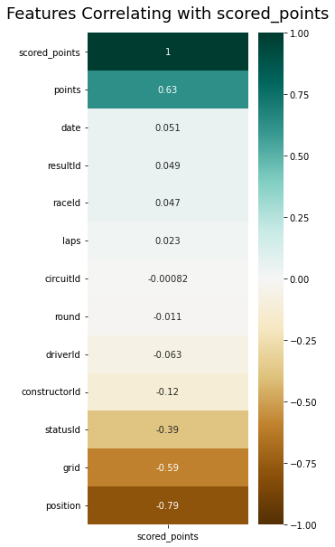

```python
# Viewing the correlation of variables with scored_points
plt.figure(figsize=(4, 10))
heatmap = sns.heatmap(df_final.corr()[['scored_points']].sort_values(by='scored_points', ascending=False), vmin=-1, vmax=1, annot=True, cmap='BrBG')
heatmap.set_title('Features Correlating with scored_points', fontdict={'fontsize':18}, pad=16)
```

```python
# Splitting the data into dependant Y and independant X variables
X = df_final.drop(['scored_points','circuitId','round','points'],axis=1)
Y = df_final['scored_points']
```

```python
# Converting Categorical data to Numeric
le = LabelEncoder()
X['driverRef'] = le.fit_transform(X['driverRef'])
X['nationality_x'] = le.fit_transform(X['nationality_x'])
X['constructorRef'] = le.fit_transform(X['constructorRef'])
```

```python
# Splitting the data into test train in the ratio 70:30
x_train, x_test,y_train,y_test = train_test_split(X,Y,test_size =0.3)
x_train
```

|  | resultId | raceId | driverId | constructorId | grid | position | laps | statusId | date | driverRef | nationality_x | constructorRef |
| --- | --- | --- | --- | --- | --- | --- | --- | --- | --- | --- | --- | --- |
| 7713 | 3724 | 194 | 56 | 6 | 4 | 3 | 62 | 1 | 893548800000000000 | 295 | 7 | 46 |
| 2 | 57 | 20 | 1 | 1 | 3 | 13 | 56 | 11 | 1207440000000000000 | 258 | 7 | 97 |
| 19934 | 14754 | 598 | 197 | 58 | 12 | 12 | 79 | 11 | 142387200000000000 | 301 | 16 | 127 |
| 17382 | 14727 | 597 | 199 | 34 | 12 | 12 | 71 | 14 | 141177600000000000 | 500 | 1 | 15 |
| 20355 | 16296 | 662 | 235 | 182 | 1 | 1 | 14 | 1 | -13046400000000000 | 291 | 5 | 19 |
| ... | ... | ... | ... | ... | ... | ... | ... | ... | ... | ... | ... | ... |
| 2613 | 22741 | 937 | 13 | 3 | 6 | 6 | 43 | 1 | 1440288000000000000 | 383 | 6 | 155 |
| 9438 | 21330 | 864 | 8 | 208 | 4 | 3 | 66 | 1 | 1336867200000000000 | 488 | 15 | 84 |
| 4091 | 4036 | 208 | 21 | 17 | 7 | 8 | 72 | 1 | 859680000000000000 | 186 | 22 | 64 |
| 6632 | 5146 | 257 | 94 | 18 | 15 | 8 | 69 | 12 | 764726400000000000 | 381 | 22 | 105 |
| 6010 | 24014 | 1000 | 807 | 4 | 13 | 12 | 69 | 11 | 1532822400000000000 | 286 | 17 | 121 |

10013 rows × 12 columns

```python
# Standardizing the data for classification
sc = StandardScaler()
x_train = sc.fit_transform(x_train)
x_test = sc.transform(x_test)
```

### Step 4: Machine Learning Modelling

#### Naive Baseline Model

```python
# Creating baseline model object
baseline_clf = GaussianNB()
```

```python
# Fitting the data into baseline model
baseline_clf.fit(x_train,y_train)
```

```
GaussianNB()
```

```python
# Predicting the values of model
ypred = baseline_clf.predict(x_test)
```

```python
# Viewing evaluation report
print(classification_report(ypred,y_test))
```

```
              precision    recall  f1-score   support

           0       0.89      0.89      0.89      2042
           1       0.90      0.90      0.90      2250

    accuracy                           0.90      4292
   macro avg       0.90      0.90      0.90      4292
weighted avg       0.90      0.90      0.90      4292
```

```python
# Viewing confusion matrix
confusion_matrix(ypred,y_test)
```

```
array([[1818,  224],
       [ 225, 2025]], dtype=int64)
```

#### Logistic Regression Classification

```python
# Creating logisticregression model object
clf = LogisticRegression()
```

```python
# Fitting the data into the model
clf.fit(x_train,y_train)
```

```
LogisticRegression()
```

```python
# Making predictions
ypred = clf.predict(x_test)
```

```python
# Viewing the evaluation report
print(classification_report(ypred,y_test))
```

```
              precision    recall  f1-score   support

           0       0.98      0.98      0.98      2041
           1       0.98      0.98      0.98      2251

    accuracy                           0.98      4292
   macro avg       0.98      0.98      0.98      4292
weighted avg       0.98      0.98      0.98      4292
```

```python
#Viewing the confusion matrix
confusion_matrix(ypred,y_test)
```

```
array([[1992,   49],
       [  51, 2200]], dtype=int64)
```

### Step 1: Load and Explore the Data

In this step we first loaded all the data into jupyter notebook with the help of Pandas library. After loading the data into the notebook we moved on Data Exploration. Here we saw what features, their types and how many null values were there in the dataset. We also referred to the data dictionary to have a better understanding of the dataset. Based on the exploration and relationship we decided to work on the following problem: We will be predicting whether a team has scored any points in a race or not.

### Step 2: Data Wrangling on multiple tables

After formulating our goal for this dataset, we moved on to merge data. We merged Four datasets in total i.e. results, races, drivers and constructors dataset. We used the primary and foreign keys to merge these datasets into a single dataframe. We had a total of 25399 rows and 36 columns. After succesfully merging the data we moved on to Data Transformation.

### Step 3: Data Cleansing and Transformation

The biggest challenge in this section was to deal with \N values which basically meant that there wasnt sufficient information for that particular row. We first converted these values to NaN values and then dealt with them efficiently.In the Data Cleaning section we first checked for duplicate rows, which were 0. Then we moved on to check for missing values. There was a large number of columns with many missing values so we decided to drop all those columns which had majority of missing values, whereas for the remaining columns we removed only a fraction of their rows. After dealing with the missing values we moved on to fixing the datatypes of variables. For the variables that could be converted to numeric, we did that where as for those variables which could not be converted to numeric, we used label encoder to convert those values to numeric datatype as machine learning model can only handle numeric values. After doing the Data Preprocessing part, we decided to create a new variable called scored_points to achieve our goal. Here if a team had scored any points, we labeled it as 1 else we labeled it as 0. This feature was our target variable whereas in order to choose predictors we created a heatmap to see the correlation of variables and we chose those variables which had to some extent a correlation with our target variable. Finally we split our dataset into test and train and then we moved on to Machine Learning Modeling.

### Step 4: Machine Learning Modelling

This was the final step for our objective. Before creating the model we decided to standardize our dataset by using StandardScaler which helps the features has a relative close value ranges. Then we created a baseline model of Naive Baye on which we fitted out dataset, trained the model on it and finally we evaluated the model by looking at various metrics such as Accuracy, F-1 Score, Precision and Recall as well as a confusion matrix. On the basis of the results we can see the at we achieved approximately 90% accuracy on the baseline model which is very good. We then created another Classification model in the form of Logistic Regression. We performed the same steps that we did for Naive Bayes and we saw that Logistic Regression actually did a much better job by achieving an accuracy of approximately 98% which is excellent.

### Conclusion

Overall we did manage to achieve our goal with a very good accuracy and performance. We performed all the neccessary steps that were required to achieve our goal.